# Lecture 6: Back Doors

Nick Huntington-Klein

2021-02-24

## Recap

- We’ve now covered how to create causal diagrams
- (aka Directed Acyclic Graphs or DAGs)
- We simply write out the list of the important variables, and draw causal arrows indicating what causes what
- This allows us to figure out what we need to do to *identify* our effect of interest

## Today

- But HOW? How does it know?
- Today we’ll be covering the *process* that lets you figure out whether you can identify your effect of interest, and how
- What do we need to condition the data on to limit ourselves just to the variation that identifies our effect of interest?
- It turns out, once we have our diagram, to be pretty straightforward
- So easy a computer can do it!

## The Back Door and the Front Door

- The basic way we’re going to be thinking about this is with a metaphor
- When you do data analysis, it’s like observing that someone left their house for the day
- When you do causal inference, it’s like asking *how they left their house*
- You want to *make sure* that they came out the *front door*, and not out the back door, not out the window, not out the chimney

## The Back Door and the Front Door

- Let’s go back to this example

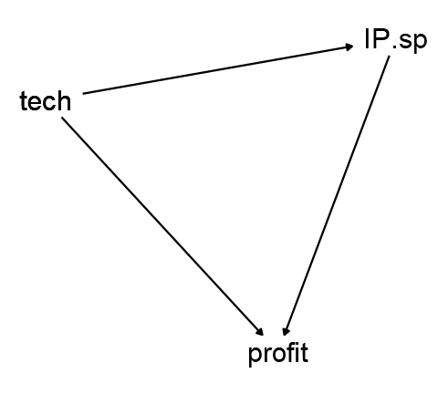

## The Back Door and the Front Door

- We’re interested in the effect of IP spend on profits. That means that our *front door* is the ways in which IP spend *causally affects* profits
- Our *back door* is any other thing that might drive a correlation between the two - the way that tech affects both

## Paths

- In order to formalize this a little more, we need to think about the various *paths*
- We observe that you got out of your house, but we want to know the paths you might have walked to get there
- So, what are the paths we can walk to get from IP.spend to profits?

## Paths

- We can go `Ip.spend -> profit`
- Or `IP.spend <- tech -> profit`

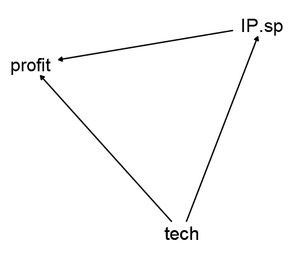

## The Back Door and the Front Door

- One of these paths is the one we’re interested in!
- `Ip.spend -> profit` is a *front door path*
- One of them is not!
- `IP.spend <- tech -> profit` is a *back door path*

## Now what?

- Now, it’s pretty simple!
- In order to make sure you came through the front door…
- We must *close the back door*
- We can do this by *controlling/adjusting* for things that will block that door!
- We can close `IP.spend <- tech -> profit` by adjusting for `tech`

## So?

- We already knew that we could get our desired effect in this case by controlling for `tech`.
- But this process lets us figure out what we need to do in a *much wider range of situations*
- All we need to do is follow the steps!
  - List all the paths
  - See which are back doors
  - Adjust for a set of variables that closes all the back doors!
- (orrrr use a method that singles out the front door - we’ll get there)

## Example

- How does wine affect your lifespan?

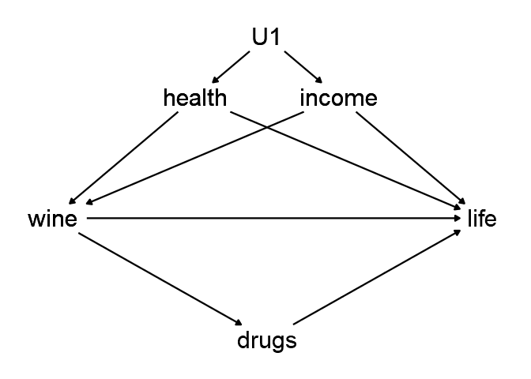

## Paths

- Paths from `wine` to `life`:
- `wine -> life`
- `wine -> drugs -> life`
- `wine <- health -> life`
- `wine <- income -> life`
- `wine <- health <- U1 -> income -> life`
- `wine <- income <- U1 -> health -> life`
- Don’t leave any out, even the ones that seem redundant!

## Paths

- Front doors/Back doors
- `wine -> life`
- `wine -> drugs -> life`
- `wine <- health -> life`
- `wine <- income -> life`
- `wine <- health <- U1 -> income -> life`
- `wine <- income <- U1 -> health -> life`

## Adjusting

- By adjusting/controlling for variables we close these back doors
- If an adjusted variable appears anywhere along the path, we can close that path off
- Once *ALL* the back door paths are closed, we have blocked all the other ways that a correlation COULD appear except through the front door! We’ve identified the causal effect!
- This is “the back door method” for identifying the effect. There are other methods; we’ll get to them.

## Adjusting for Health

- Front doors/Open back doors/Closed back doors
- `wine -> life`
- `wine -> drugs -> life`
- `wine <- health -> life`
- `wine <- income -> life`
- `wine <- health <- U1 -> income -> life`
- `wine <- income <- U1 -> health -> life`

## Adjusting for Health

- Clearly, adjusting for health isn’t ENOUGH to identify
- We need to adjust for health AND income
- Conveniently, regression makes it easy to add additional controls

## Adjusting for Health and Income

- Front doors/Open back doors/Closed back doors
- `wine -> life`
- `wine -> drugs -> life`
- `wine <- health -> life`
- `wine <- income -> life`
- `wine <- health <- U1 -> income -> life`
- `wine <- income <- U1 -> health -> life`

## How about Drugs?

- Should we adjust for drugs?
- No! This whole procedure makes that clear
- It’s on a *front door path*
- If we adjusted for that, that’s shutting out part of the way that `wine` *DOES* affect `life`

## Practice

- We want to know how `X` affects `Y`. Find all paths and make a list of what to adjust for to close all back doors

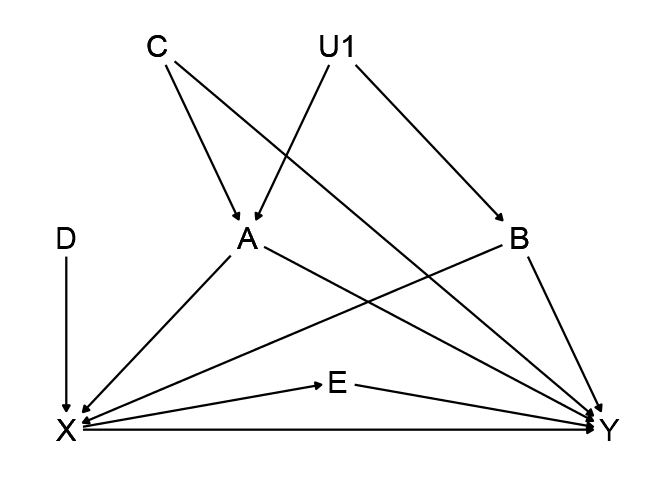

## Practice Answers

- Front door paths: `X -> Y`, `X -> E -> Y`
- Back doors: `X <- A -> Y`, `X <- B -> Y`, `X <- A <- U1 -> B -> Y`, `X <- B <- U1 -> A -> Y`, `X <- A <- C -> Y`, `X <- B <- U1 -> A <- C -> Y`
- (that last back door is actually pre-closed, we’ll get to that later)
- We can close all back doors by adjusting for `A` and `B`.

## Controlling

- So… what does it actually mean to control for something?
- Often the way we *will do it* is just by adding a control variable to a regression. In $Y = \beta_0 + \beta_1X + \beta_2Z + \varepsilon$, the $\hat{\beta}_1$ estimate gives the effect of $X$ on $Y$ *while controlling for $Z$, and if adjusting for $Z$ closes all back doors, we’ve identified the effect of $X$ on $Y$!
- But what does it *mean*?

## Controlling

- The *idea* of controlling for a variable is that we want to *remove all parts of the $X$/$Y$ relationship that is related to that variable*
- I.e. we want to *remove all variation related to that variable*
- A regression control will do this (although it will only do it *linearly*), but anything that achieves this goal will work!
- For example, if you want to “control for income”, we could add income as a regression control, *or* we could pick a sample only made up of people with very similar incomes
- No variation in $Z$: $Z$ is controlled for!

## The Two Main Approaches to Controlling

Predicting Variation (what regression does):

- Use $Z$ (and the other controls) to predict both $X$ and $Y$ as best you can
- Remove all the predictable parts, and use only remaining variation, which is unrelated (orthogonal) to $Z$

Selecting Non-Variation (what “matching” does):

- Choose observations that have different values of $X$ but have values of $Z$ that are as similar as possible
- With multiple controls, this requires some way of combining them together to get a single “similarity” value

## The Two Main Approaches to Controlling

- In this class we’ll be focusing mostly on regression
- Purely because that’s what economists do most of the time
- Regression and matching rely on slightly different assumptions to work, but neither is better than the other
- Newfangled “doubly-robust” methods do both regression AND matching, so that the model only fails if the assumptions of BOTH methods fail
- So then, focusing on the “predicting variation” approach…

## Controlling

- Up to now, here’s how we’ve been getting the relationship between `X` and `Y` while controlling for `W`:
1. See what part of `X` is explained by `W`, and subtract it out. Call the result the residual part of `X`.
2. See what part of `Y` is explained by `W`, and subtract it out. Call the result the residual part of `Y`.
3. Get the relationship between the residual part of `X` and the residual part of `Y`.
- With the last step including things like getting the correlation, plotting the relationship, calculating the variance explained, or comparing mean `Y` across values of `X`

## In code

```r
df <- tibble(w = rnorm(100)) %>%
  mutate(x = 2*w + rnorm(100)) %>%
  mutate(y = 1*x + 4*w + rnorm(100))
df <- df %>%
  mutate(x.resid = x - predict(lm(x~w)),
         y.resid = y - predict(lm(y~w)))
m1 <- lm(y~x, data = df)
m2 <- lm(y.resid ~ x.resid, data = df)
m3 <- lm(y~x+w, data = df)
msummary(list(m1,m2,m3), stars = TRUE, gof_omit = 'Adj|AIC|BIC|F|Lik')
```

## In code

|  | Model 1 | Model 2 | Model 3 |
| --- | --- | --- | --- |
| (Intercept) | -0.217 | 0.000 | -0.055 |
|  | (0.198) | (0.098) | (0.099) |
| x | 2.679*** |  | 0.960*** |
|  | (0.092) |  | (0.109) |
| x.resid |  | 0.960*** |  |
|  |  | (0.109) |  |
| w |  |  | 4.057*** |
|  |  |  | (0.234) |
| Num.Obs. | 100 | 100 | 100 |
| R2 | 0.896 | 0.442 | 0.975 |

* p < 0.1, ** p < 0.05, *** p < 0.01

## In Diagrams

- The relationship between `X` and `Y` reflects both `X->Y` and `X<-W->Y`
- We remove the part of `X` and `Y` that `W` explains to get rid of `X<-W` and `W->Y`, blocking `X<-W->Y` and leaving `X->Y`

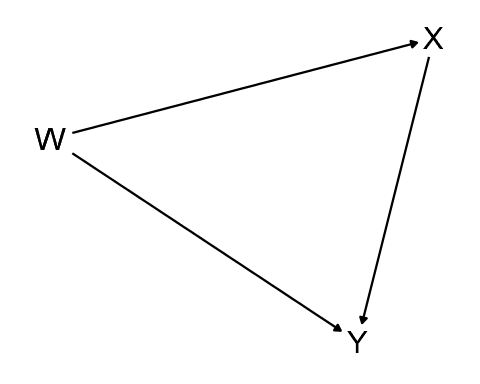

## Graphically

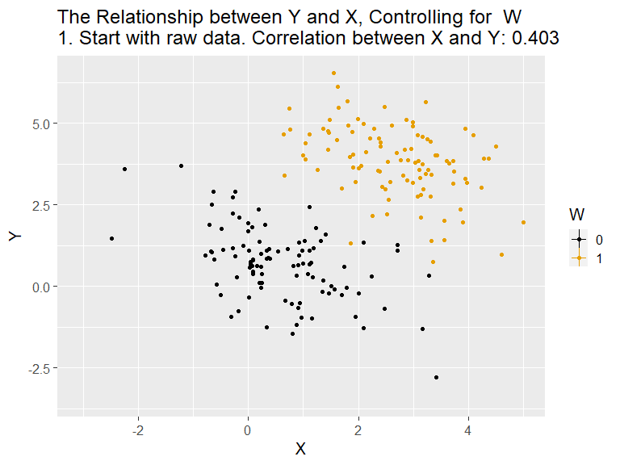

## Intuitively

- So this is all about removing variation explanined by the control variable
- That’s why you hear some people refer to controlling as “holding `W` constant” - we literally remove the variation in `W`, leaving it “constant”
- Another way of thinking of it is that you’re looking for variation of `X` and `Y` *within* values of `W` - this is made clear in the animation
- **Comparing apples to apples**

## An Example

- We’ll borrow an example from the Wooldridge econometrics textbook (data available in the `wooldridge` package)
- LaLonde (1986) is a study of whether a job training program improves earnings in 1978 (`re78`)
- Specifically, it has data on an *experiment* of *assigning* people to a job training program (data `jtrain2`)
- And also data on people who *chose* to participate in that program, or didn’t (data `jtrain3`)
- The goal of causal inference - do something to `jtrain3` so it gives us the “correct” result from `jtrain2`

## LaLonde

```r
library(wooldridge)
#EXPERIMENT
data(jtrain2)
jtrain2 %>% group_by(train) %>% summarize(wage = mean(re78))
```

```
## # A tibble: 2 x 2
##   train  wage
## * <int> <dbl>
## 1     0  4.55
## 2     1  6.35
```

```r
#BY CHOICE
data(jtrain3)
jtrain3 %>% group_by(train) %>% summarize(wage = mean(re78))
```

```
## # A tibble: 2 x 2
##   train  wage
## * <int> <dbl>
## 1     0 21.6
## 2     1  6.35
```

## Hmm…

- What back doors might the `jtrain3` analysis be facing?
- People who need training want to get it but are likely to get lower wages anyway!

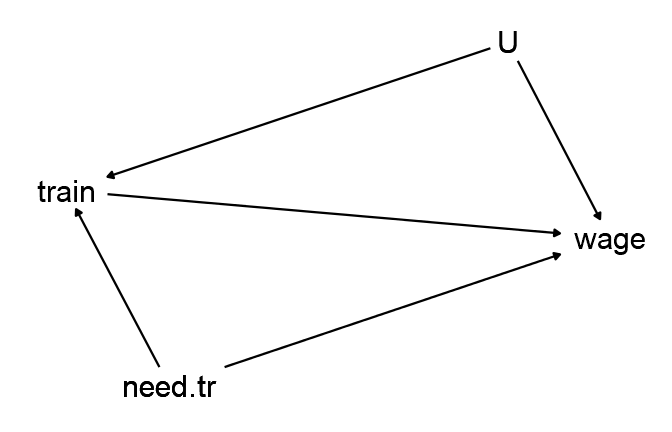

## Apples to Apples

- The two data sets are looking at very different groups of people!

```r
library(vtable)
sumtable(select(jtrain2,re75,re78), out = 'return')
```

```
##   Variable   N  Mean Std. Dev. Min Pctl. 25 Pctl. 75    Max
## 1     re75 445 1.377     3.151   0        0    1.221 25.142
## 2     re78 445 5.301     6.631   0        0    8.125 60.308
```

```r
sumtable(select(jtrain3,re75,re78), out = 'return')
```

```
##   Variable    N   Mean Std. Dev. Min Pctl. 25 Pctl. 75     Max
## 1     re75 2675 17.851    13.878   0    7.605   25.584 156.653
## 2     re78 2675 20.502    15.633   0    9.243   28.816 121.174
```

## Controlling

- We can’t measure “needs training” directly, but we can sort of control for it by limiting ourselves solely to the kind of people who need it - those who had low wages in 1975

```
## # A tibble: 2 x 2
##   train  wage
## * <int> <dbl>
## 1     0  4.55
## 2     1  6.35
```

```
## # A tibble: 2 x 2
##   train  wage
## * <int> <dbl>
## 1     0  5.62
## 2     1  6.00
```

## Controlling

- Not exactly the same (not surprising - we were pretty arbitrary in how we controlled for `need.tr`, and we never closed `train <- U -> wage`, oh and we left out plenty of other back doors: race, age, etc.) but an improvement
- This is a demonstration of controlling by choosing a sample; we could also just control for 1975 wages

## Controlling

|  | Model 1 | Model 2 |
| --- | --- | --- |
| (Intercept) | 21.554*** | 5.653*** |
|  | (0.304) | (0.360) |
| train | -15.205*** | -0.582 |
|  | (1.155) | (0.841) |
| re75 |  | 0.834*** |
|  |  | (0.015) |
| Num.Obs. | 2675 | 2675 |
| R2 | 0.061 | 0.553 |

* p < 0.1, ** p < 0.05, *** p < 0.01

## Bad Controls

- So far so good - we have the concept of what it means to control and some ways we can do it, so we can get apples-to-apples comparisons
- But what should we control for?
- Everything, right? We want to make sure our comparison is as apple-y as possible!
- Well, no, not actually

## Bad Controls

- Some controls can take you away from showing you the front door
- We already discussed how it’s not a good idea to block a front-door path.
- An increase in the price of cigarettes might improve your health, but not if we control for the number of cigarettes you smoke!

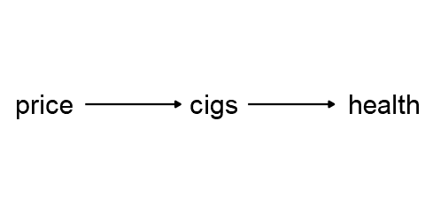

## Bad Controls

- There is another kind of bad control - a *collider*
- Basically, if you’re listing out paths, and you see a path where the arrows *collide* by both pointing at the same variable, **that path is already blocked**
- Like this: `X <- W -> C <- Z -> Y`
- Note the `-> C <-`. Those arrow are colliding!
- If we control for the collider `C`, *that path opens back up!*

## Colliders

- One kind of diagram (of many) where this might pop up:

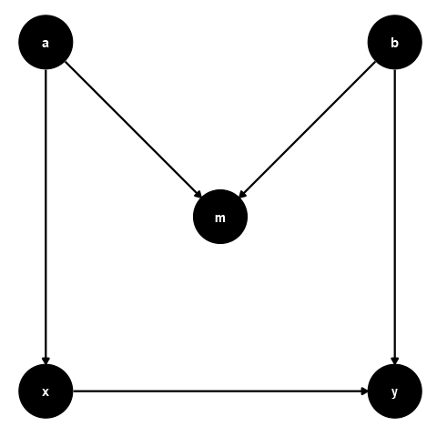

## Colliders

- How could this be?
- Because even if two variables *cause* the same thing (`a -> m`, `b -> m`), that doesn’t make them related. Your parents both caused your genetic makeup, that doesn’t make *their* genetics related. Knowing dad’s eye color tells you nothing about mom’s.
- But *within given values of the collider*, they ARE related. If you’re brown-eyed, then observing that your dad has blue eyes tells us that your mom is brown-eyed

## Colliders

- So here, `x <- a -> m <- b -> y` is pre-blocked, no problem. `a` and `b` are unrelated, so no back door issue!
- Control for `m` and now `a` and `b` are related, back door path open.

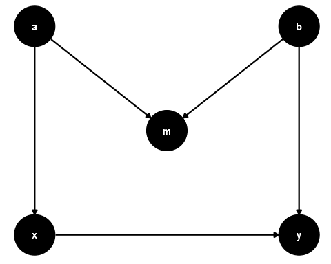

## Example

- You want to know if programming skills reduce your social skills
- So you go to a tech company and test all their employees on programming and social skills
- Let’s imagine that the *truth* is that programming skills and social skills are unrelated
- But you find a negative relationship! What gives?

## Example

- Oops! By surveying only the tech company, you controlled for “works in a tech company”
- To do that, you need programming skills, social skills, or both! It’s a collider!

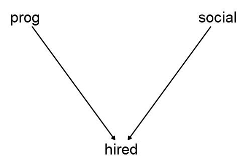

## Example

```r
set.seed(14233)
survey <- tibble(prog=rnorm(1000),social=rnorm(1000)) %>%
  mutate(hired = (prog + social > .25))
# Truth
m1 <- lm(social~prog, data = survey)

#Controlling by just surveying those hired
m2 <- lm(social~prog, data = survey %>% filter(hired == 1))

#Surveying everyone and controlling with our normal method
m3 <- lm(social ~ prog + hired, data = survey)

msummary(list(m1,m2,m3), stars = TRUE, gof_omit = 'Adj|BIC|AIC|Lik|F')
```

## Example

|  | Model 1 | Model 2 | Model 3 |
| --- | --- | --- | --- |
| (Intercept) | -0.047 | 0.932*** | -0.756*** |
|  | (0.032) | (0.046) | (0.036) |
| prog | 0.036 | -0.468*** | -0.429*** |
|  | (0.031) | (0.041) | (0.029) |
| hiredTRUE |  |  | 1.659*** |
|  |  |  | (0.061) |
| Num.Obs. | 1000 | 432 | 1000 |
| R2 | 0.001 | 0.229 | 0.428 |

* p < 0.1, ** p < 0.05, *** p < 0.01

## Graphically

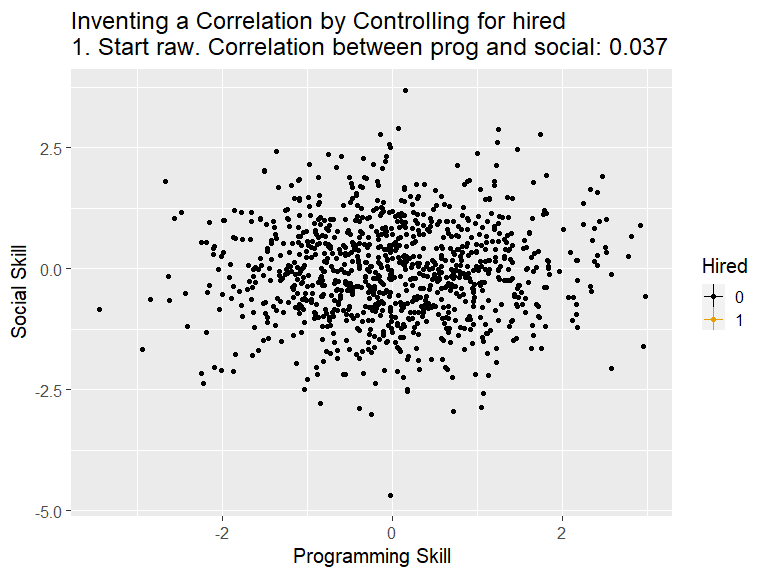

## Colliders

- This doesn’t just create correlations from nothing, it can also distort causal effects that ARE there
- For example, did you know that height is UNrelated to basketball skill… among NBA players?

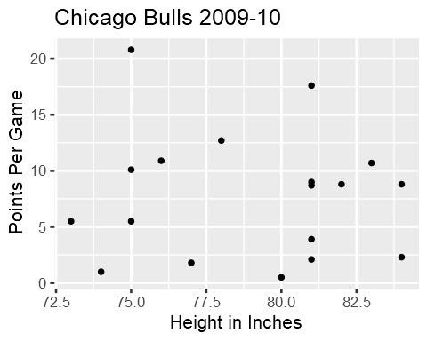

## Colliders

- Sometimes, things can get real tricky
- In some cases, the same variable NEEDS to be controlled for to close a back door path, but it’s a collider on ANOTHER back door path!
- In those cases you just can’t identify the effect, at least not easily
- This pops up in estimates of the gender wage gap - example from Cunningham’s Mixtape: should you control for occupation when looking at gender discrimination in the labor market?

## Colliders in the Gender Wage Gap

- We are interested in `gender -> discrim -> wage`; our treatment is `gender -> discrim`, the discrimination caused by your gender

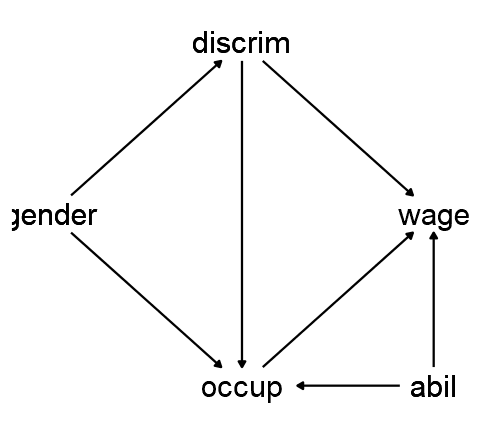

## Colliders in the Gender Wage Gap

- Front doors/Open back doors/Closed back doors
- `gender -> discrim -> wage`
- `gender -> discrim -> occup -> wage`
- `discrim <- gender -> occup -> wage`
- `discrim <- gender -> occup <- abil -> wage`
- `gender -> discrim -> occup <- abil -> wage`

## Colliders in the Gender Wage Gap

- No `occup` control? Ignore nondiscriminatory reasons to choose different occupations by gender
- Control for `occup`? Open both back doors, create a correlation between `abil` and `discrim` where there wasn’t one
- And also close a FRONT door, `gender -> discrim -> occup -> wage`: discriminatory reasons for gender diffs in `occup`
- We actually *can’t* identify the effect we want in this diagram by controlling. It happens!
- Suggests this question goes beyond just controlling for stuff. Real research on this topic gets clever.

## Next Time

- Perhaps one of the ways we could get at the problem is by isolating *front doors* instead of focusing on closing *back doors*
- Many common causal inference methods combine the two!
- Next time we’ll look at the concept of isolating a front door path, usually using “natural experiments”

## Practice

- We want to know how `X` affects `Y`. Find all paths and make a list of what to adjust for to close all back doors

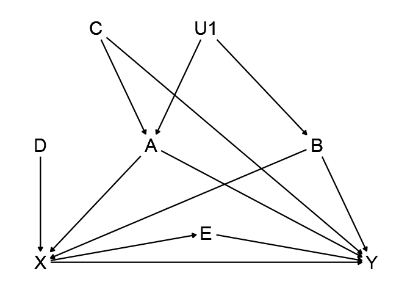

## Practice Answers

- Front door paths: `X -> Y`, `X -> E -> Y`
- Back doors: `X <- A -> Y`, `X <- B -> Y`, `X <- A <- U1 -> B -> Y`, `X <- B <- U1 -> A -> Y`, `X <- A <- C -> Y`, `X <- B <- U1 -> A <- C -> Y`
- (`X <- B <- U1 -> A <- C -> Y` is pre-closed by a collider)
- We can close all back doors by adjusting for `A` and `B`.